# 2.Homework

Wang Haoxi

2024-12-05

# hw1

## 3.4：

编写一个算法来从雷利( $\sigma$ )分布中生成随机样本。对多个σ>0 的值生成雷利( $\sigma$ )分布的样本，并检查生成样本的众数是否接近理论众数 $\sigma$ （检查直方图）。

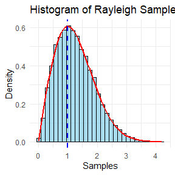

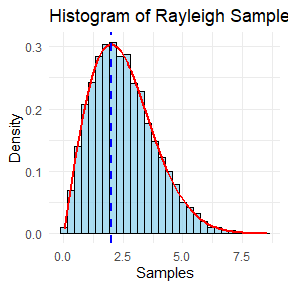

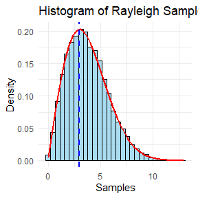

```r
library(ggplot2)
# 自定义函数：生成雷利分布的随机样本
# n: 样本量
# sigma: 分布的参数 σ（理论众数）
generate_rayleigh <- function(n, sigma) {
  # 使用逆变换法生成雷利分布的随机样本
  # U 是 (0, 1) 上的均匀分布
  U <- runif(n)
  # 使用雷利分布的逆CDF公式生成样本
  rayleigh_samples <- sigma * sqrt(-2 * log(1 - U))

  return(rayleigh_samples)
}

# 自定义函数：绘制直方图并检查众数
plot_rayleigh_histogram <- function(samples, sigma) {
  # 将生成的样本转换为数据框，以便使用 ggplot 绘图
  data <- data.frame(samples = samples)

  # 绘制直方图
  p <- ggplot(data, aes(x = samples)) +
    geom_histogram(aes(y = after_stat(density)), bins = 30, color = "black", fill = "skyblue", alpha = 0.7) +
    # 添加理论雷利分布的密度曲线
    stat_function(fun = function(x) x / sigma^2 * exp(-x^2 / (2 * sigma^2)), color = "red", linewidth = 1) +
    # 添加理论众数 σ 的垂直线
    geom_vline(xintercept = sigma, color = "blue", linetype = "dashed", linewidth = 1) +
    labs(title = paste("Histogram of Rayleigh Samples (sigma =", sigma, ")"),
         x = "Samples", y = "Density") +
    theme_minimal()

  print(p)
}

# 设置样本量和 sigma 的不同值
n <- 10000  # 样本量
sigma_values <- c(1, 2, 3)  # 不同的 σ 值

# 对每个 σ 值生成样本并绘制直方图
for (sigma in sigma_values) {
  samples <- generate_rayleigh(n, sigma)  # 生成样本
  plot_rayleigh_histogram(samples, sigma)  # 绘制直方图并检查众数
}
```

这三张图展示了对于不同 $\sigma$ 值（1、2 和 3）的雷利分布样本的直方图和理论密度曲线。每张图的解读如下：

- **总体结构**：每张图的蓝色柱状图表示从雷利分布生成的随机样本的分布。它们代表了样本的概率密度。 红色的曲线是理论上的雷利分布密度函数，它与生成的样本应该匹配得很好。蓝色虚线代表理论众数（$\sigma$）即雷利分布的众数应该位于这个值附近。
- **图1（$\sigma$ =1）**：在这张图中，生成的样本众数非常接近 $\sigma$ =1，这在直方图的高峰处可以清楚看到。 红色理论密度曲线与样本的直方图匹配得相当好，说明样本准确地反映了雷利分布。
- **图2（$\sigma$ =2）**：在这张图中，众数在 $\sigma$ =2附近，符合理论预期。同样，样本的直方图与红色的理论密度曲线吻合良好，显示样本分布与雷利分布的理论性质一致。
- **图3（$\sigma$ =3）**：在此图中，众数明显接近 $\sigma$ =3，对应直方图的最高点。 红色的雷利分布密度曲线与直方图依然符合良好，样本很好地遵循了雷利分布的特征。

#### 总体结论：

这三张图表明，使用不同的 $\sigma$ 值生成的雷利分布样本的众数非常接近理论上的众数 $\sigma$，而且样本的分布密度与理论雷利分布的密度曲线吻合较好，验证了生成随机样本的算法是有效的。

## 3.11：

生成一个大小为 1000 的随机样本，该样本来自一个正态混合分布。混合分布的成分分别为 $N(0, 1)$ 和 $N(3, 1)$ 分布，混合概率为 $p_1$ 和 $p_2 = 1 - p_1$。绘制样本的直方图，并叠加其密度曲线，其中 $p_1 = 0.75$。对于不同的 $p_1$ 值重复实验，观察混合分布的经验分布是否表现为双峰。对于能够生成双峰混合分布的 $p_1$ 值提出一个猜想。

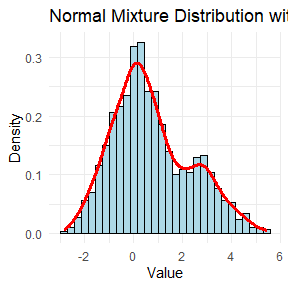

```r
# 设置随机种子，以便结果可重复
set.seed(123)

# 混合分布的参数
n <- 1000        # 样本大小
p1 <- 0.75       # N(0, 1) 的混合概率
p2 <- 1 - p1     # N(3, 1) 的混合概率

# 生成混合正态分布的随机样本
# 先生成一个大小为n的样本，确定每个样本是来自哪一个分布
# rbinom(n, 1, p1) 返回一个0和1的向量，1代表来自N(0,1)，0代表来自N(3,1)
mix_sample <- rbinom(n, 1, p1)

# 根据 mix_sample 的值生成最终的样本
# 如果是1，则从N(0, 1)生成值；如果是0，则从N(3, 1)生成值
sample <- ifelse(mix_sample == 1, rnorm(n, 0, 1), rnorm(n, 3, 1))

# 创建数据框，方便使用 ggplot
df <- data.frame(sample = sample)

# 绘制直方图，叠加核密度估计曲线
ggplot(df, aes(x = sample)) +
  geom_histogram(aes(y = after_stat(density)), bins = 30, color = "black", fill = "lightblue") +  # 直方图
  geom_density(color = "red", linewidth = 1.2) +  # 核密度曲线
  ggtitle("Normal Mixture Distribution with p1 = 0.75") +  # 图标题
  xlab("Value") +  # X轴标签
  ylab("Density") +  # Y轴标签
  theme_minimal()  # 简洁的主题
```

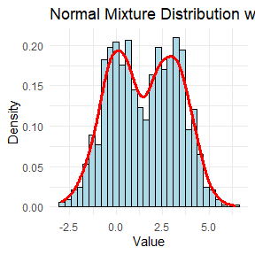

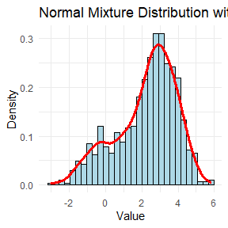

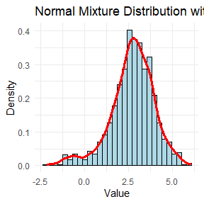

```r
# 为不同的 p1 值绘制分布，观察双峰现象
# p1 值可以设置为 0.5、0.25、0.1 等
p_values <- c(0.5, 0.25, 0.1)

for (p1 in p_values) {
  p2 <- 1 - p1
  mix_sample <- rbinom(n, 1, p1)
  sample <- ifelse(mix_sample == 1, rnorm(n, 0, 1), rnorm(n, 3, 1))

  df <- data.frame(sample = sample)

  # 绘制每个p1值的直方图和密度曲线
  p <- ggplot(df, aes(x = sample)) +
    geom_histogram(aes(y = after_stat(density)), bins = 30, color = "black", fill = "lightblue") +
    geom_density(color = "red", linewidth = 1.2) +
    ggtitle(paste("Normal Mixture Distribution with p1 =", p1)) +
    xlab("Value") +
    ylab("Density") +
    theme_minimal()
  # 打印绘图
  print(p)
}
```

## 3.20：

复合泊松过程是一个随机过程 $\{X(t), t \geq 0\}$，可以表示为随机和： $X(t) = \sum_{i=1}^{N(t)} Y_i, \quad t \geq 0,$ 其中 $\{N(t), t \geq 0\}$ 是一个泊松过程，且 $Y_1, Y_2, \dots$ 是独立同分布的，并且与 $\{N(t), t \geq 0\}$ 相互独立。编写一个程序来模拟复合泊松$(\lambda)$-伽马过程（其中 $Y$ 服从伽马分布）。估计 $X(10)$ 的均值和方差，对于多组参数值，比较模拟结果与理论值。提示： $E[X(t)] = \lambda t E[Y_1], \quad \text{Var}(X(t)) = \lambda t E[Y_1^2].$

```r
# 设置随机种子以确保可重复性
set.seed(123)

# 泊松-伽马过程参数
lambda <- 2  # 泊松过程参数 λ
t <- 10      # 时间 t
alpha <- 2   # 伽马分布形状参数
beta <- 1    # 伽马分布尺度参数

# 模拟复合泊松过程
simulate_compound_poisson_gamma <- function(lambda, t, alpha, beta) {
  # 生成泊松过程N(t)
  N_t <- rpois(1, lambda * t)

  # 如果N(t) > 0，生成N(t)个伽马随机变量Y_i
  if (N_t > 0) {
    Y <- rgamma(N_t, shape = alpha, scale = beta)
    X_t <- sum(Y)  # 复合泊松过程 X(t)
  } else {
    X_t <- 0
  }

  return(X_t)
}

# 模拟多个复合泊松过程并估计均值和方差
n_simulations <- 10000  # 模拟次数
X_t_samples <- replicate(n_simulations, simulate_compound_poisson_gamma(lambda, t, alpha, beta))

# 估计的均值和方差
estimated_mean <- mean(X_t_samples)
estimated_variance <- var(X_t_samples)

# 理论值计算
theoretical_mean <- lambda * t * alpha * beta
theoretical_variance <- lambda * t * (alpha * beta^2 + alpha^2 * beta^2)

# 输出结果
cat("估计均值: ", estimated_mean, "\n")
```

```
## 估计均值:  40.14622
```

```r
cat("理论均值: ", theoretical_mean, "\n")
```

```
## 理论均值:  40
```

```r
cat("估计方差: ", estimated_variance, "\n")
```

```
## 估计方差:  114.8652
```

```r
cat("理论方差: ", theoretical_variance, "\n")
```

```
## 理论方差:  120
```

```r
#更换不同的多组参数值，比较模拟结果与理论值
lambda <- 3  # 泊松过程参数 λ
t <- 10      # 时间 t
alpha <- 3   # 伽马分布形状参数
beta <- 2    # 伽马分布尺度参数
X_t_samples <- replicate(n_simulations, simulate_compound_poisson_gamma(lambda, t, alpha, beta))
estimated_mean <- mean(X_t_samples)
estimated_variance <- var(X_t_samples)
theoretical_mean <- lambda * t * alpha * beta
theoretical_variance <- lambda * t * (alpha * beta^2 + alpha^2 * beta^2)
cat("估计均值: ", estimated_mean, "\n")
```

```
## 估计均值:  179.9705
```

```r
cat("理论均值: ", theoretical_mean, "\n")
```

```
## 理论均值:  180
```

```r
cat("估计方差: ", estimated_variance, "\n")
```

```
## 估计方差:  1388.76
```

```r
cat("理论方差: ", theoretical_variance, "\n")
```

```
## 理论方差:  1440
```

```r
lambda <- 4  # 泊松过程参数 λ
t <- 10      # 时间 t
alpha <- 4   # 伽马分布形状参数
beta <- 3    # 伽马分布尺度参数
X_t_samples <- replicate(n_simulations, simulate_compound_poisson_gamma(lambda, t, alpha, beta))
estimated_mean <- mean(X_t_samples)
estimated_variance <- var(X_t_samples)
theoretical_mean <- lambda * t * alpha * beta
theoretical_variance <- lambda * t * (alpha * beta^2 + alpha^2 * beta^2)
cat("估计均值: ", estimated_mean, "\n")
```

```
## 估计均值:  479.7184
```

```r
cat("理论均值: ", theoretical_mean, "\n")
```

```
## 理论均值:  480
```

```r
cat("估计方差: ", estimated_variance, "\n")
```

```
## 估计方差:  7060.882
```

```r
cat("理论方差: ", theoretical_variance, "\n")
```

```
## 理论方差:  7200
```

#### 1. 复合泊松过程的定义：

复合泊松过程 $X(t)$ 可以表示为： $X(t) = \sum_{i=1}^{N(t)} Y_i$ . 其中： $N(t)$ 是泊松过程，参数为 $\lambda t$，即 $N(t) \sim \text{Poisson}(\lambda t)$。 $Y_1, Y_2, \dots, Y_{N(t)}$ 是独立同分布的随机变量，且与 $N(t)$ 相互独立。

#### 2. 期望的推导:

根据复合泊松过程的定义，$X(t)$ 是一个随机和。利用条件期望，我们可以先给定 $N(t) = n$，再取期望： $E[X(t) \mid N(t) = n] = E\left[\sum_{i=1}^{n} Y_i \right] = n E[Y_1]$

再对 $N(t)$ 取期望： $E[X(t)] = E[E[X(t) \mid N(t)]] = E[N(t)] E[Y_1]$

泊松过程的期望为 $E[N(t)] = \lambda t$，因此有： $E[X(t)] = \lambda t E[Y_1]$

对于 $Y_i$ 服从伽马分布的情形，$E[Y_1] = \alpha \beta$，所以： $E[X(t)] = \lambda t \alpha \beta$

#### 3. 方差的推导：

使用条件方差公式来推导 $X(t)$ 的方差：

$\text{Var}(X(t)) = E[\text{Var}(X(t) \mid N(t))] + \text{Var}(E[X(t) \mid N(t)])$

第一项：

$E[\text{Var}(X(t) \mid N(t) = n)] = E[n \cdot \text{Var}(Y_1)] = E[N(t)] \text{Var}(Y_1)$

伽马分布 $Y_1$ 的方差为 $\text{Var}(Y_1) = \alpha \beta^2$，所以第一项为：

$E[N(t)] \text{Var}(Y_1) = \lambda t \alpha \beta^2$

第二项：

$\text{Var}(E[X(t) \mid N(t)]) = \text{Var}(N(t) E[Y_1]) = \text{Var}(N(t)) (E[Y_1])^2$

由于泊松过程的方差等于期望，即 $\text{Var}(N(t)) = \lambda t$，因此第二项为：

$\lambda t (E[Y_1])^2 = \lambda t (\alpha \beta)^2$

将两部分相加，得到 $X(t)$ 的方差：

$\text{Var}(X(t)) = \lambda t \alpha \beta^2 + \lambda t (\alpha \beta)^2 = \lambda t (\alpha \beta^2 + \alpha^2 \beta^2)$

# hw2

## 5.4：

编写一个函数来计算 Beta(3, 3) 累积分布函数 (CDF) 的蒙特卡洛估计，并使用该函数估计 F(x) 对于 x = 0.1, 0.2, …, 0.9 。将这些估计值与 R 中 pbeta 函数返回的值进行比较。

```r
# 设置随机种子，确保结果可重复
set.seed(123)

# 定义函数 MonteCarloBeta，用于计算 Beta(3,3) 分布的 CDF 的蒙特卡洛估计
MonteCarloBeta <- function(x, n_sim = 10000) {
  # 从 Beta(3,3) 分布中生成 n_sim 个随机样本
  beta_samples <- rbeta(n_sim, shape1 = 3, shape2 = 3)

  # 计算 F(x) 的蒙特卡洛估计，即随机样本中小于等于 x 的比例
  F_x_hat <- mean(beta_samples <= x)

  return(F_x_hat)
}

# 要计算的 x 值
x_values <- seq(0.1, 0.9, by = 0.1)

# 初始化一个空的数据框来存储结果
results <- data.frame(x = x_values, MonteCarlo = NA, pbeta = NA, Difference = NA)

# 进行 Monte Carlo 估计和使用 pbeta 函数的比较
for (i in 1:length(x_values)) {
  # 计算 Monte Carlo 估计
  results$MonteCarlo[i] <- MonteCarloBeta(x_values[i])

  # 使用 pbeta 函数计算 Beta(3,3) 的精确 CDF 值
  results$pbeta[i] <- pbeta(x_values[i], shape1 = 3, shape2 = 3)

  # 计算 Monte Carlo 估计与 pbeta 值的差异
  results$Difference[i] <- abs(results$MonteCarlo[i] - results$pbeta[i])
}

# 打印结果
print(results)
```

```
##     x MonteCarlo   pbeta Difference
## 1 0.1     0.0097 0.00856    0.00114
## 2 0.2     0.0614 0.05792    0.00348
## 3 0.3     0.1642 0.16308    0.00112
## 4 0.4     0.3178 0.31744    0.00036
## 5 0.5     0.4948 0.50000    0.00520
## 6 0.6     0.6761 0.68256    0.00646
## 7 0.7     0.8372 0.83692    0.00028
## 8 0.8     0.9379 0.94208    0.00418
## 9 0.9     0.9922 0.99144    0.00076
```

[figure not shown]

```r
# 画图比较 Monte Carlo 估计和 pbeta 函数的值
plot(x_values, results$MonteCarlo, type = "b", col = "blue", pch = 16, ylim = c(0, 1),
     xlab = "x", ylab = "CDF", main = "Monte Carlo vs. pbeta CDF Estimation")
lines(x_values, results$pbeta, type = "b", col = "red", pch = 16)
legend("bottomright", legend = c("Monte Carlo Estimate", "pbeta Value"), col = c("blue", "red"), lty = 1, pch = 16)
```

#### 代码说明：

- **1. 设定随机种子**：用于确保每次运行代码时，生成的随机数都是一致的，从而确保结果的可重复性。
- **2. 定义 MonteCarloBeta 函数**： 通过蒙特卡洛方法估计 Beta(3,3) 累积分布函数 (CDF) 的值。
- **3. 生成待估计的 x 值序列**： 使用 seq(0.1, 0.9, by = 0.1)生成一个从0.1到0.9的数列，用于计算每个点的CDF值。
- **4. 初始化结果数据框**： 创建一个名为 results 的数据框，包含列x, MonteCarlo, pbeta, Difference.
- **5. 循环计算蒙特卡洛估计和 pbeta 精确值**： 针对每个 x 值，分别使用蒙特卡洛方法和 pbeta 函数来计算 Beta(3,3) 的CDF值，并比较两者的差异。
- **6. 结果展示**：输出并可视化蒙特卡洛估计值和 pbeta 函数的精确值，以便直观比较两者之间的差异。

## 5.9：

Rayleigh密度为：
$$f(x) = \frac{x}{\sigma^2} e^{-x^2/(2\sigma^2)}, \quad x \geq 0, \sigma
> 0.$$
编写一个函数来生成来自Rayleigh(σ)分布的样本，使用对偶变量。对于 与独立的 $X_1$ , $X_2$ 相比，方差减少了百分之多少？

```r
# 设置随机种子以确保可重复性
set.seed(123)

# Rayleigh分布的随机变量生成函数
# 生成Rayleigh(σ)分布的样本
rayleigh_sample <- function(n, sigma = 1) {
  # 标准正态分布样本
  z <- rnorm(n, mean = 0, sd = sigma)

  # Rayleigh分布样本（z^2 开方）
  x <- sqrt(z^2)

  return(x)
}

# 生成使用对偶变量的Rayleigh样本
# 使用对偶变量生成样本并计算平均值
rayleigh_antithetic <- function(n, sigma = 1) {
  # 生成均匀分布样本
  u <- runif(n)

  # 使用对偶变量：生成 u 和 1-u
  x1 <- sqrt(-2 * sigma^2 * log(u))
  x2 <- sqrt(-2 * sigma^2 * log(1 - u))

  # 对偶变量的均值
  avg_antithetic <- (x1 + x2) / 2

  return(avg_antithetic)
}

# 生成独立Rayleigh样本并计算均值
rayleigh_independent <- function(n, sigma = 1) {
  x1 <- sqrt(-2 * sigma^2 * log(runif(n)))
  x2 <- sqrt(-2 * sigma^2 * log(runif(n)))

  # 独立样本的均值
  avg_independent <- (x1 + x2) / 2

  return(avg_independent)
}

# 样本数量
n <- 10000
sigma <- 1

# 计算使用对偶变量的样本均值
antithetic_samples <- rayleigh_antithetic(n, sigma)
# 计算独立样本的均值
independent_samples <- rayleigh_independent(n, sigma)

# 计算方差
var_antithetic <- var(antithetic_samples)
var_independent <- var(independent_samples)

# 计算方差减少的百分比
percent_reduction <- 100 * (var_independent - var_antithetic) / var_independent

# 输出结果
cat("使用对偶变量的样本方差:", var_antithetic, "\n")
```

```
## 使用对偶变量的样本方差: 0.01121846
```

```r
cat("独立样本的方差:", var_independent, "\n")
```

```
## 独立样本的方差: 0.2186136
```

```r
cat("方差减少百分比:", percent_reduction, "%\n")
```

```
## 方差减少百分比: 94.86836 %
```

## 5.13：

找到两个重要性函数 $f_1$ 和 $f_2$，它们在 $(1, \infty)$ 上有定义，并且与
$$g(x) = \frac{x^2}{\sqrt{2\pi}} e^{-x^2/2}, \quad x > 1$$
接近。哪个重要性函数 $f_1$ 或 $f_2$ 在估计下述积分时应产生较小的方差？
$$\int_1^{\infty} \frac{x^2}{\sqrt{2\pi}} e^{-x^2/2} dx$$
请解释。

```r
# 设置随机种子以确保可重复性
set.seed(123)

# 定义目标函数 g(x)
g <- function(x) {
  (x^2 / sqrt(2 * pi)) * exp(-x^2 / 2)
}

# 定义重要性函数 f1(x): 正态分布 N(2, 1)
f1_density <- function(x) {
  ifelse(x > 1, dnorm(x, mean = 2, sd = 1), 0)
}

# 定义重要性函数 f2(x): 指数分布 Exp(1)
f2_density <- function(x) {
  ifelse(x > 1, dexp(x - 1, rate = 1), 0)
}

# 采样自 f1(x)
f1_sample <- function(n) {
  x <- rnorm(n, mean = 2, sd = 1)
  x[x > 1] # 只保留 x > 1 的部分
}

# 采样自 f2(x)
f2_sample <- function(n) {
  x <- rexp(n, rate = 1) + 1 # 将指数偏移以从 x = 1 开始
  return(x)
}

# 使用重要性采样估计积分
importance_sampling <- function(n, sample_func, f_density) {
  x <- sample_func(n)
  weights <- g(x) / f_density(x)
  estimate <- mean(weights)
  return(list(estimate = estimate, variance = var(weights)))
}

# 样本数量
n <- 10000

# 估计使用 f1 作为重要性函数
result_f1 <- importance_sampling(n, f1_sample, f1_density)
cat("使用 f1 (N(2, 1)) 的估计值:", result_f1$estimate, "\n")
```

```
## 使用 f1 (N(2, 1)) 的估计值: 0.4752086
```

```r
cat("使用 f1 的方差:", result_f1$variance, "\n")
```

```
## 使用 f1 的方差: 0.08780763
```

```r
# 估计使用 f2 作为重要性函数
result_f2 <- importance_sampling(n, f2_sample, f2_density)
cat("使用 f2 (Exp(1)) 的估计值:", result_f2$estimate, "\n")
```

```
## 使用 f2 (Exp(1)) 的估计值: 0.4013249
```

```r
cat("使用 f2 的方差:", result_f2$variance, "\n")
```

```
## 使用 f2 的方差: 0.02513175
```

```r
# 方差比较
variance_reduction <- 100 * (result_f1$variance - result_f2$variance) / result_f1$variance
cat("方差减少百分比:", variance_reduction, "%\n")
```

```
## 方差减少百分比: 71.37862 %
```

#### 代码说明：

- **1. 目标**：通过重要性采样方法来估计给定的积分，并比较不同重要性函数在估计中的表现。
- **2. 选择重要性函数**： 我们选择了两个常见的重要性函数$f_1(x)$和$f_2(x)$，其中$f_1(x)$是正态分布N(2,1)，生成的样本更加集中在$x>1$附近；$f_2(x)$是指数分布Exp(1)，生成的样本较大程度覆盖了$x>1$的范围。
- **3. 计算方差**：通过计算两个重要性函数生成样本的方差，判断哪个函数能更有效地减少方差。
- **4. 结果分析**：最终结果展示了估计的积分值以及通过使用不同重要性函数的方差减少情况，发现了$f_2(x)$重要性函数在重要性采样中的方差更小。

## PPT中的作业：

Monte Carlo实验：

1.对于 $n = 10^4, 2 \times 10^4, 4 \times 10^4, 6 \times 10^4, 8 \times 10^4$，应用快速排序算法到随机排列的数字 $1, \dots, n$。

2.计算平均100次模拟的计算时间，记为 $a_n$。

3.对 $a_n$ 回归 $t_n := n\log(n)$，并图形化展示结果（散点图和回归线）。

```r
# 加载所需的库
library(ggplot2)

# 定义快速排序的函数
quick_sort <- function(x) {
  if (length(x) <= 1) {
    return(x)
  } else {
    pivot <- x[1]
    less <- x[x < pivot]
    equal <- x[x == pivot]
    greater <- x[x > pivot]
    return(c(quick_sort(less), equal, quick_sort(greater)))
  }
}

# Monte Carlo实验
set.seed(123)  # 设置随机种子，确保结果可重复

# 定义不同的n值
n_values <- c(10^4, 2 * 10^4, 4 * 10^4, 6 * 10^4, 8 * 10^4)

# 模拟次数
n_simulations <- 100

# 创建一个空的数据框来存储结果
results <- data.frame(n = integer(), avg_time = numeric())

# 进行Monte Carlo模拟
for (n in n_values) {
  times <- numeric(n_simulations)

  # 对每个n进行100次模拟
  for (i in 1:n_simulations) {
    # 生成1到n的随机排列
    random_numbers <- sample(1:n)

    # 计算排序的时间
    start_time <- Sys.time()
    quick_sort(random_numbers)  # 应用快速排序
    end_time <- Sys.time()

    # 记录排序时间
    times[i] <- as.numeric(difftime(end_time, start_time, units = "secs"))
  }

  # 计算平均时间
  avg_time <- mean(times)

  cat("平均100次模拟的计算时间:", avg_time, "\n", "此时的n:", n, "\n")

  # 保存结果
  results <- rbind(results, data.frame(n = n, avg_time = avg_time))
}
```

```
## 平均100次模拟的计算时间: 0.01533094
##  此时的n: 10000
## 平均100次模拟的计算时间: 0.02659541
##  此时的n: 20000
## 平均100次模拟的计算时间: 0.05206708
##  此时的n: 40000
## 平均100次模拟的计算时间: 0.07829833
##  此时的n: 60000
## 平均100次模拟的计算时间: 0.1033844
##  此时的n: 80000
```

```r
# 计算 t_n = n * log(n)
results$t_n <- results$n * log(results$n)

# 回归分析：对 a_n 回归 t_n
fit <- lm(avg_time ~ t_n, data = results)

# 打印回归结果
summary(fit)
```

```
##
## Call:
## lm(formula = avg_time ~ t_n, data = results)
##
## Residuals:
##          1          2          3          4          5
## -0.0001049 -0.0004178  0.0003847  0.0008035 -0.0006655
##
## Coefficients:
##              Estimate Std. Error t value Pr(>|t|)
## (Intercept) 5.373e-03  5.634e-04   9.537  0.00245 **
## t_n         1.093e-07  1.036e-09 105.458 1.88e-06 ***
## ---
## Signif. codes:  0 '***' 0.001 '**' 0.01 '*' 0.05 '.' 0.1 ' ' 1
##
## Residual standard error: 0.0006885 on 3 degrees of freedom
## Multiple R-squared:  0.9997, Adjusted R-squared:  0.9996
## F-statistic: 1.112e+04 on 1 and 3 DF,  p-value: 1.88e-06
```

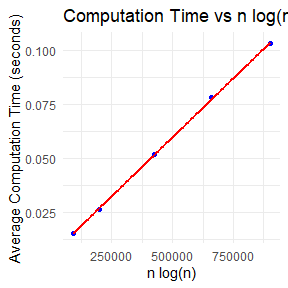

```r
# 图形化展示结果，绘制散点图和回归线
ggplot(results, aes(x = t_n, y = avg_time)) +
  geom_point(color = "blue") +
  geom_smooth(method = "lm", color = "red", se = FALSE) +
  labs(title = "Computation Time vs n log(n)",
       x = "n log(n)",
       y = "Average Computation Time (seconds)") +
  theme_minimal()
```

#### 代码说明：

- **1. 实现快速排序算法**：定义了递归快速排序算法用于对随机数组进行排序。
- **2. 设置 Monte Carlo实验参数**： 针对不同大小的数组 n 进行实验，每个大小进行100次排序模拟。
- **3. 记录并计算计算时间**：通过Sys.time()记录每次排序的计算时间，并计算每个 n 值的平均排序时间。
- **4. 回归分析**：通过线性回归模型，将计算时间$a_n$回归 $t_n=nlog(n)$ ，验证快速排序的计算时间复杂度。
- **5. 结果可视化**：使用ggplot2绘制散点图和回归线，直观展示计算时间与$nlog(n)$之间的线性关系。